#### 22.11.23, © Kudryavets Yehor KI-21-1, 2023

# Лабораторна робота №5. OpenCV. Геометричні перетворення зображення

**Мета:** знайомство з методами геометричних перетворень бібліотеки OpenCV у середовищі Anaconda із застосуванням Jupyter Notebook засобами мови програмування Python.

# Хід роботи

1.Імпортувати RGB-зображення Image з диску. Оцінити його розмір у пікселях та об’єм пам’яті, який він займає на диску.

```
Image Analysis: 1920x1080 pixels, 3 channels
File Size on Disk: 6220800 bytes
```

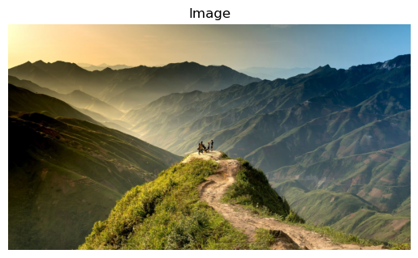

```python
import cv2 as cv
import numpy as np
import matplotlib.pyplot as plt

def process_image(image_path):
    img = cv.imread(image_path)
    height, width, channels = img.shape
    file_size = np.prod(img.shape)

    print(f'Image Analysis: {width}x{height} pixels, {channels} channels')
    print(f'File Size on Disk: {file_size} bytes')

    plt.imshow(cv.cvtColor(img, cv.COLOR_BGR2RGB))
    plt.axis('off')
    plt.title('Image')
    plt.show()

new_image_path = 'img/1.jpg'

process_image(new_image_path)
```

2.Імпортувати RGB-зображення Image у напівтоновому форматі. Оцінити його розмір у пікселях та об’єм пам’яті, який він займає на диску. Порівняти результати з попередніми результатами. Пояснити результати.

```
Image Size in Pixels: 1920x1080
Memory Footprint on Disk: 2073600 bytes
```

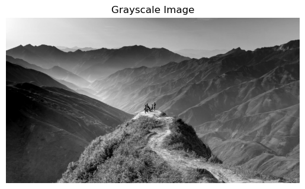

```python
import cv2 as cv
import numpy as np
import matplotlib.pyplot as plt

def process_grayscale_image(image_path):
    img = cv.imread(image_path, cv.IMREAD_GRAYSCALE)
    height, width = img.shape
    image_size_bytes = img.nbytes

    print(f'Image Size in Pixels: {width}x{height}')
    print(f'Memory Footprint on Disk: {image_size_bytes} bytes')

    plt.imshow(img, cmap='gray')
    plt.title('Grayscale Image')
    plt.axis('off')
    plt.show()

image_path = 'img/1.jpg'

process_grayscale_image(image_path)
```

RGB зображення мають більший об'єм інформації через наявність трьох каналів кольору для кожного пікселя. У напівтонових зображеннях лише один канал (градація сірого або альфа-канал, якщо він присутній). Тому напівтонові зображення містять менше даних для збереження.

3.Зменшити початкове RGB-зображення Image у разів, візуалізувати його, перевіривши результат масштабування, та експортувати його на диск. Чи змінився об’єм пам’яті, який він займає на диску? Обгрунтувати отриманий результат.

```
Original Image Size: 1920x1080
Memory Footprint on Disk: 6220800 bytes
```

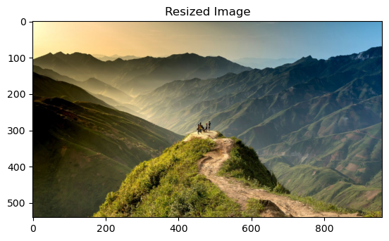

```
Resized Image Size: 960x540 pixels
File Size on Disk for Resized Image: 190276 bytes
```

```python
import cv2
import math
import matplotlib.pyplot as plt
import os

def resize_and_show_image(input_path, output_path):
    img = cv2.imread(input_path)

    print(f'Original Image Size: {img.shape[1]}x{img.shape[0]} ')
    print(f'Memory Footprint on Disk: {img.size} bytes')

    rows, cols = img.shape[:2]
    new_rows = math.floor(rows / 2)
    new_cols = math.floor(cols / 2)

    resized_img = cv2.resize(img, (new_cols, new_rows), interpolation=cv2.INTER_AREA)
    plt.imshow(cv2.cvtColor(resized_img, cv2.COLOR_BGR2RGB))
    plt.title('Resized Image')
    plt.show()

    cv2.imwrite(output_path, resized_img)
    print(f'Resized Image Size: {new_cols}x{new_rows} pixels')

    file_size = os.path.getsize(output_path)
    print(f'File Size on Disk for Resized Image: {file_size} bytes')

input_img_path = 'img/1.jpg'
output_img_path = 'img/2.jpg'

resize_and_show_image(input_img_path, output_img_path)
```

Об'єм пам'яті, який займає зображення на диску, залежить від кількості пікселів та рівня стиснення при збереженні. У цьому випадку розмір зображення зменшився на половину, що вплинуло на об'єм файлу.

4.Написати функцію, яка буде виконувати пропорційне зменшення початкового зображення розміром пікселей відповідно до вимоги, щоби зменешене зображення мало ширину пікселей.

[figure not shown]

[output not shown]

```python
import cv2
import matplotlib.pyplot as plt
import os

def resize_and_display_image(input_path, output_path, target_width):
    image = cv2.imread(input_path)

    height, width, channels = image.shape
    new_height = int(height * (target_width / width))

    resized_image = cv2.resize(image, (target_width, new_height), interpolation=cv2.INTER_AREA)

    plt.imshow(cv2.cvtColor(resized_image, cv2.COLOR_BGR2RGB))
    plt.title('Зменшене зображення')
    plt.show()

    cv2.imwrite(output_path, resized_image)
    print(f"Розмір зменшеного зображення: {target_width}x{new_height} пікселів")

    file_size = os.path.getsize(output_path)
    print(f"Розмір файлу на диску зменшеного зображення: {file_size} байт")

input_image_path = 'img/1.jpg'
output_image_path = 'img/1.5.jpg'
target_width = 300

resize_and_display_image(input_image_path, output_image_path, target_width)
```

[figure not shown]

```python
import cv2 as cv
import numpy as np
import matplotlib.pyplot as plt

def apply_affine_transform(input_path, output_path, input_points, output_width, output_height):
    img = cv.imread(input_path)

    if img is None:
        print("Error: Unable to load the image.")
    else:
        output_points = np.float32(
            [
                [0, 0],
                [output_width, 0],
                [0, output_height]
            ]
        )

        affine_transform_matrix = cv.getAffineTransform(input_points, output_points)
        img_affine_transformed = cv.warpAffine(img, affine_transform_matrix, (output_width, output_height))

        img_rgb = cv.cvtColor(img, cv.COLOR_BGR2RGB)
        plt.subplot(121)
        plt.imshow(img_rgb)
        plt.title('Input')

        img_affine_transformed_rgb = cv.cvtColor(img_affine_transformed, cv.COLOR_BGR2RGB)
        plt.subplot(122)
        plt.imshow(img_affine_transformed_rgb)
        plt.title('Affine Transformation')

        cv.imwrite(output_path, img_affine_transformed)
        plt.show()

input_points = np.float32(
    [
        [60, 150],
        [940, 150],
        [60, 810]
    ]
)
output_width = 800
output_height = 600

output_path = 'img/output_photo.jpg'

apply_affine_transform('img/photo.jpg', output_path, input_points, output_width, output_height)
```

[figure not shown]

```python
import cv2 as cv
import numpy as np
import matplotlib.pyplot as plt

def apply_affine_transform(input_path, output_path, input_points, output_width, output_height):
    img = cv.imread(input_path)

    if img is None:
        print("Error: Unable to load the image.")
    else:
        output_points = np.float32(
            [
                [0, 0],
                [output_width, 0],
                [0, output_height]
            ]
        )

        affine_transform_matrix = cv.getAffineTransform(input_points, output_points)
        img_affine_transformed = cv.warpAffine(img, affine_transform_matrix, (output_width, output_height))

        img_rgb = cv.cvtColor(img, cv.COLOR_BGR2RGB)
        plt.subplot(121)
        plt.imshow(img_rgb)
        plt.title('Input')

        img_affine_transformed_rgb = cv.cvtColor(img_affine_transformed, cv.COLOR_BGR2RGB)
        plt.subplot(122)
        plt.imshow(img_affine_transformed_rgb)
        plt.title('Affine Transformation')

        cv.imwrite(output_path, img_affine_transformed)
        plt.show()

input_points = np.float32(
    [
        [60, 150],
        [940, 150],
        [60, 810]
    ]
)
output_width = 800
output_height = 600

output_path = 'img/output_photo.jpg'

apply_affine_transform('img/photo.jpg', output_path, input_points, output_width, output_height)
```

## Контрольні запитання

1.У чому полягає сенс афінних перетворень?

Сенс афінних перетворень полягає в їхній здатності змінювати форму та розмір об'єктів у двовимірному просторі, зберігаючи паралельність ліній і відношення відстаней між точками. Це робить їх корисними для зміни розміру, обертання та зсуву об'єктів у графіці, обробці зображень і комп'ютерному зорі.

2.Чи є оперції трансляції, масштабування і повороту афінними? Відповідь обгрунтувати.

Афінні перетворення включають в себе трансляцію (зсув), масштабування і поворот як основні операції для модифікації геометричних об'єктів у двовимірному просторі. Трансляція дозволяє зсувати об'єкт вздовж осей X і Y, зберігаючи його форму та розмір. Масштабування дозволяє збільшувати або зменшувати розмір об'єкта вздовж цих осей, з відношенням до початкового розміру. Поворот дозволяє обертати об'єкт навколо центральної точки, зберігаючи паралельність ліній і відношення відстаней між точками.

3.Чи є перспективні перетворення частинним випадком афінних перетворень? Відповідь обгрунтувати.

Перспективні перетворення і афінні перетворення є двома різними класами геометричних перетворень в двовимірному просторі. Основна відмінність полягає в тому, як вони впливають на паралельність ліній та відношення відстаней між точками.У випадку афінних перетворень, які включають в себе трансляцію, масштабування та поворот, паралельні лінії залишаються паралельними після перетворення, і відношення відстаней між точками залишаються незмінними. Це дозволяє зберігати геометричну форму об'єкта. Перспективні перетворення, з іншого боку, не зберігають паралельність ліній та відношення відстаней між точками. Це дозволяє їм моделювати ефекти перспективи, такі як зближеність об'єктів на далекому плані, що знаходяться на однаковій відстані від спостерігача.

## References

1.https://github.com/wtfpanda007/Python - посилання на GitHub-репозиторій